# Zonas eleitorais

William Peixoto

25 de junho de 2018

As zonas eleitorais são compostas de seções, onde os eleitores efetivamente votam. O TSE divulga as informações agrupadas por zona e por seção. Nesta página, apenas os dados agrupados pelo TSE serão analisados.

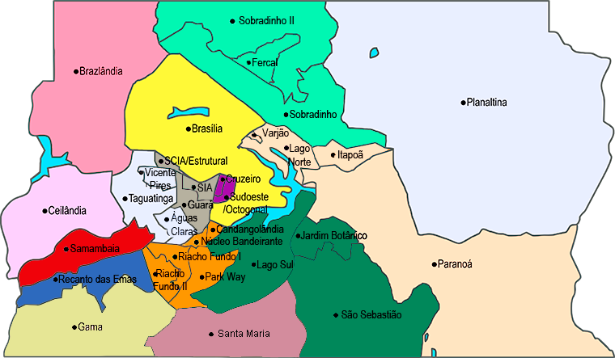

A quantidade de zonas aumentou junto com a população de eleitores. Eram 14 em 1998 e são 21 hoje.

# 1 Distribuições de frequências

# 2 Distribuições de frequências

Mais detalhes na página específica.

# 3 Comparações

Apesar de as distribuições evidentemente não serem Normais, serão usados seus métodos para exercitar os conhecimentos adquiridos no curso.

## 3.1 Comparações entre turnos

Para eleições no mesmo ano, há razões suficientes para considerar que sejam observações sucessivas em uma mesma população (Lei das Eleições).

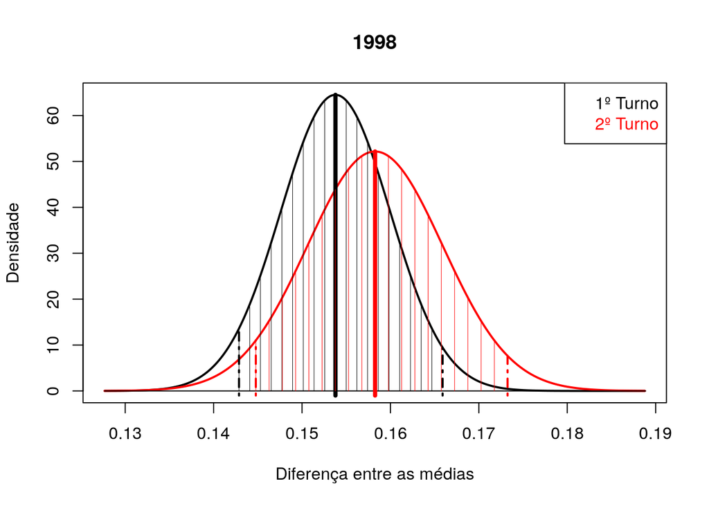

```
## [1] "z-calc 2.71309795157309 p= 0.0033"
```

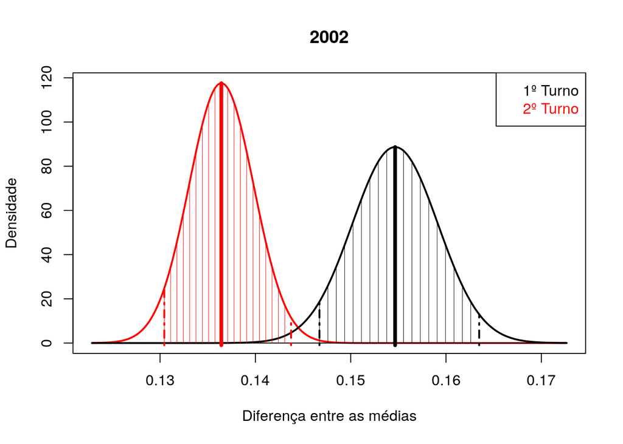

```
## [1] "z-calc 16.7081260876791 p= 0"
```

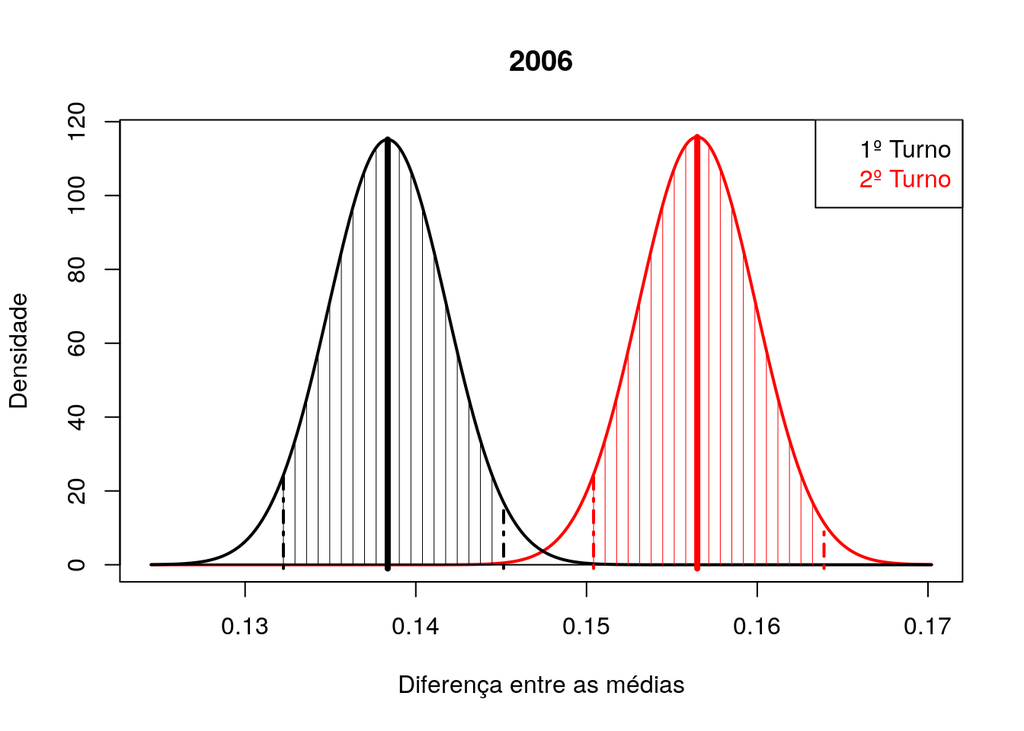

```
## [1] "z-calc 21.5808830929949 p= 0"
```

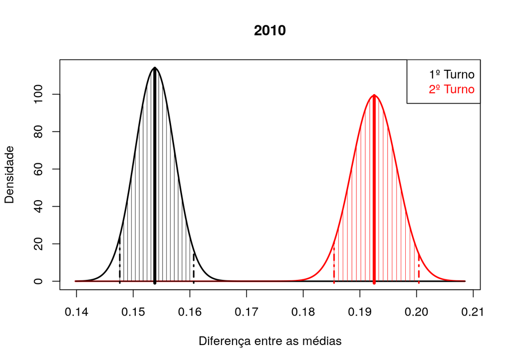

```
## [1] "z-calc 50.6667008317341 p= 0"
```

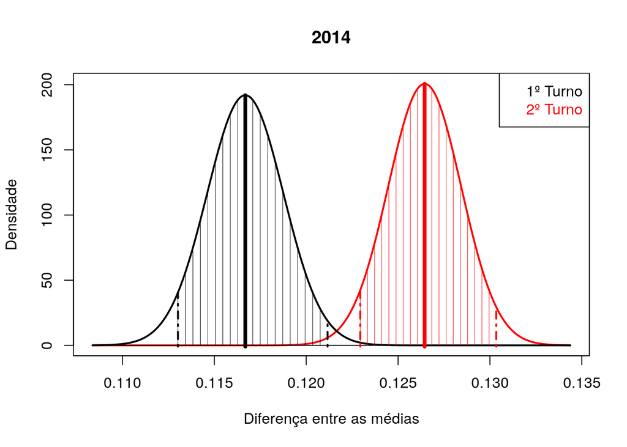

```
## [1] "z-calc 21.5295994618338 p= 0"
```

### 3.1.1 Resultados

TODO: A comparação abaixo é geral. Falta comparar dois a dois para calcular região crítica

Comparações entre turnos

| ano | media | t | p_value | low | upp |
| --- | --- | --- | --- | --- | --- |
| 1998 | -0.0044836 | -2.319456 | 0.0372869 | -0.0086596 | -0.0003075 |
| 2002 | 0.0182313 | 4.187563 | 0.0006964 | 0.0090019 | 0.0274606 |
| 2006 | -0.0181316 | -28.833151 | 0.0000000 | -0.0194647 | -0.0167985 |
| 2010 | -0.0387168 | -32.445390 | 0.0000000 | -0.0412060 | -0.0362276 |
| 2014 | -0.0097631 | -4.395273 | 0.0002793 | -0.0143967 | -0.0051296 |

Esses resultados podem ser visualizados no seguinte gráfico:

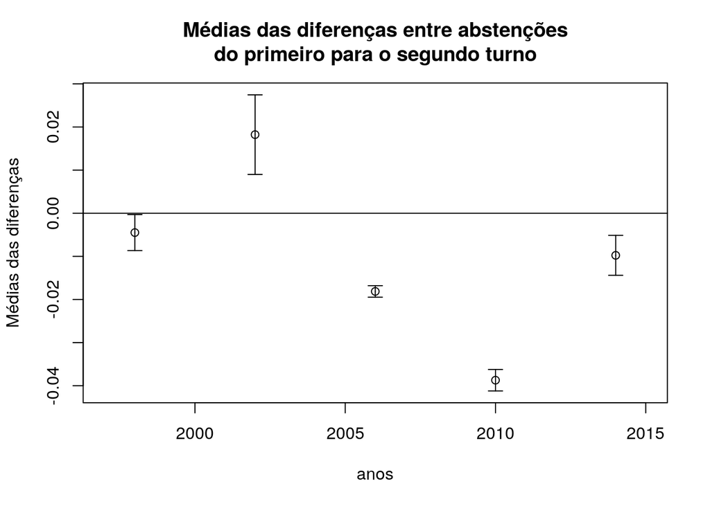

Observe-se que, para 1998, o intervalo de confiança chega muito perto da igualdade estatística entre as taxas de abstenção do primeiro para o segundo turno. Nessa eleição, houve segundo turno apenas para governador.

### 3.1.2 Força dos testes

TODO: Calcular região crítica

#### 3.1.2.1 Hipóteses

- $H_0: \mu = 0$
- $H_a: \mu \neq 0$

#### 3.1.2.2 Região crítica

#### 3.1.2.3 Erros

- $\alpha = P(x < -x_c | \mu = 0) + P(x > x_c | \mu = 0)$
- $\beta = P(-x_c < x < x_c| \mu \neq 0)$
- Força do teste = $1-\beta$
- $x_c =$ média do primeiro turno $ +1.96 S$ SE

```r
# source("NormalPadrao.R")


# dnormalComp()
```

## 3.2 Comparações entre anos distintos

Foram consideradas independentes as eleições ocorridas em anos distintos.

Para comparar anos distintos, serão comparados o segundo turno de um ano com o primeiro do outro. Devido às transformações no eleitorado, as amostras serão consideradas indepententes.

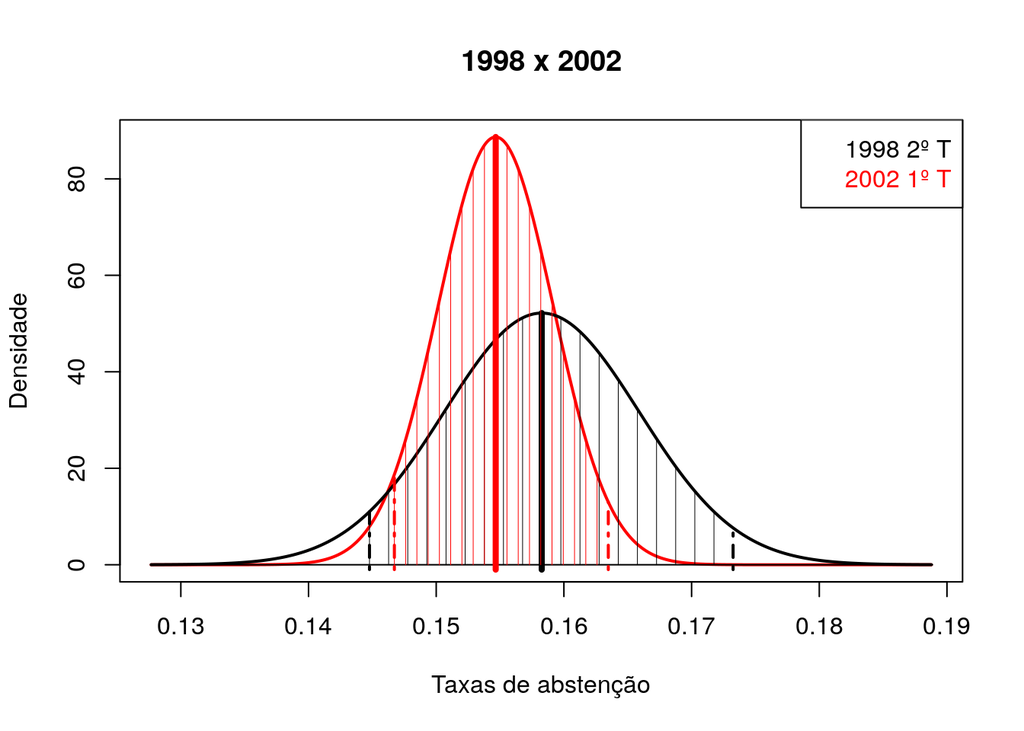

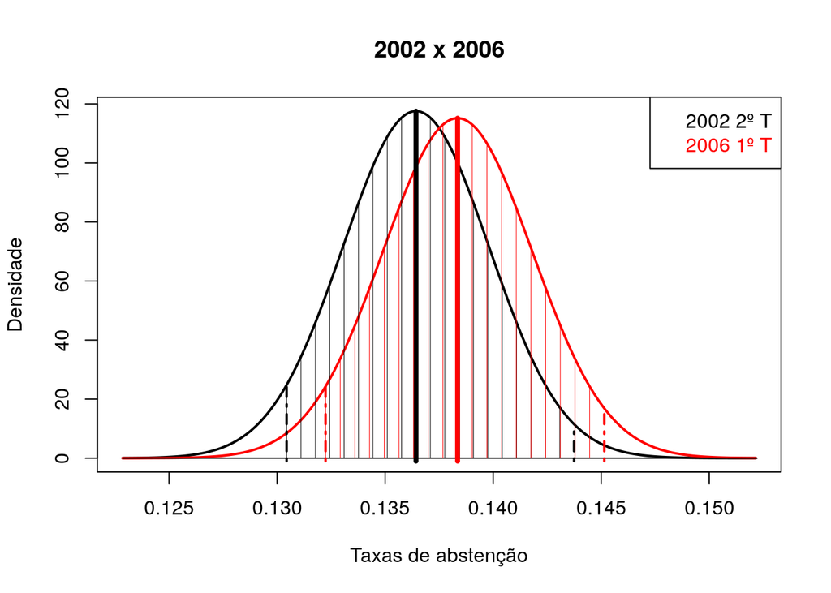

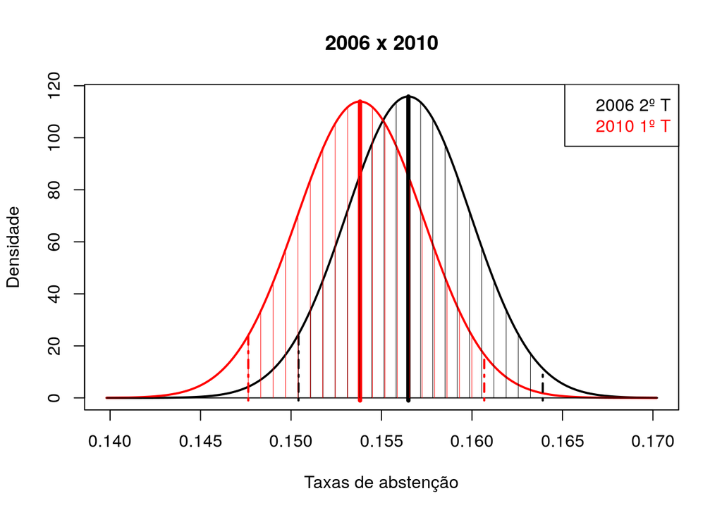

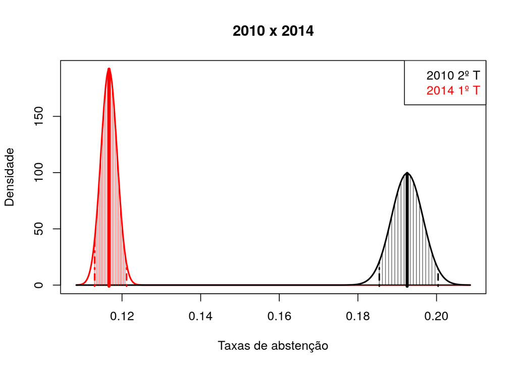

Comparações entre anos distintos

[output not shown]

Nas três primeiras comparações, não é possível rejeitar $H_0$. Apenas entre 2010 e 2014 foi verificada uma distinção bastante significativa (p << 0.05)

### 3.2.1 Força dos testes

#### 3.2.1.1 Hipóteses

- $H_0: \mu_i = \mu_{i+1}$
- $H_a: \mu_1 \neq \mu_{i+1}$

#### 3.2.1.2 Regiões críticas

#### 3.2.1.3 Erros

- $\alpha = P(x < -x_c | \mu_i = \mu_{i+1}) + P(x > x_c | \mu_i = \mu_{i+1})$
- $\beta = P(-x_c < x < x_c | \mu_1 \neq \mu_{i+1}$
- Força do teste = $1-\beta$